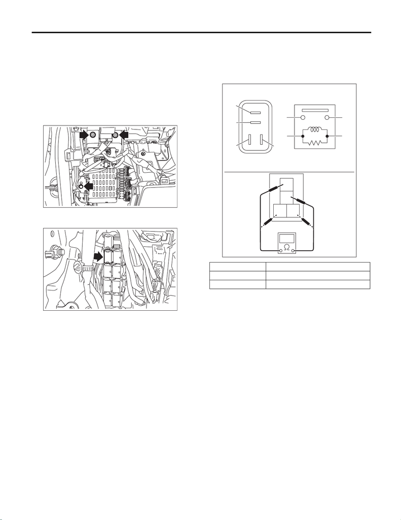

FU(STI)-60

Electronic Throttle Control Relay

FUEL INJECTION (FUEL SYSTEMS)

22.Electronic Throttle Control

Relay

A: REMOVAL

1) Disconnect the ground cable from battery.

2) Remove the instrument panel lower cover. <Ref.

to EI-61, REMOVAL, Instrument Panel Lower Cov-

er.>

3) Remove the bolts and nuts securing the fuse

block and move down the fuse block.

4) Remove the electronic throttle control relay from

the relay block.

B: INSTALLATION

Install in the reverse order of removal.

Tightening torque:

7.5 N·m (0.8 kgf-m, 5.5 ft-lb)

C: INSPECTION

1) Check that the electronic throttle control relay

has no deformation, cracks or other damages.

2) Measure the resistance between electronic

throttle control relay terminals.

FU-08390

FU-08392

Terminal No. Standard

1 and 2 1 MΩ or more

3 and 4 93.8 — 136.4 Ω (when 20°C (68°F))

1

2

3

4

(1)

(2)

(1)

(4)

(2)

(3)

(3)

(4)

IN-02836

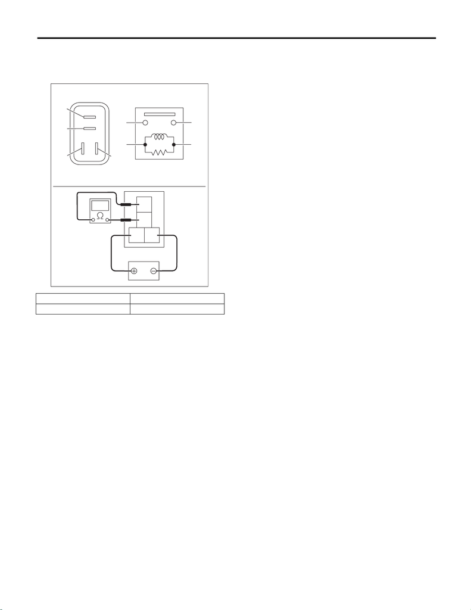

FU(STI)-61

Electronic Throttle Control Relay

FUEL INJECTION (FUEL SYSTEMS)

3) Connect battery positive terminal to terminal No.

3 and battery ground terminal to terminal No. 4, and

measure the resistance between the electronic

throttle control relay terminals.

Terminal No. Standard

1 and 2 Less than 1 Ω

FU-04077

1

2

3

4

(1)

(2)

(1)

(4)

(2)

(3)

(3)

(4)